# The Workforce in Crisis: Understanding the Link between State-Level COVID-19 Responses and Low-Income Employment

## Report Info

This report was written by Yarra Abozaed, Janelle Acob, Zach Johansen, and Tim Chen, for DAT 4500 (Data and Society), taught by Dr. Gill, due on June 8th, 2023.

## Abstract

The COVID-19 pandemic has disproportionately impacted low-income workers, resulting in significant job losses around the world. This paper examines the relationship between the responses to the pandemic in the United States and the impact of such responses on the low-income job market. We examine a set of relevant variables that are correlated to the loss of low-income jobs and use said variables to create a predictive model using principal component analysis.

## Introduction

The COVID-19 pandemic has had a lasting impact on the global economy, reshaping the way companies engage with customers and manage their internal operations. Among the groups most heavily affected by the pandemic are low-income job holders, who experienced unstable employment conditions from 2020 to 2022. We define low-income jobs in this report as those where workers earn less than $40,000 annually. While federal actions were implemented in the United States, some states independently adopted measures to mitigate the spread of COVID-19.

This paper aims to examine the correlation between the COVID-19 response measures implemented by each state and their impact on the workforce, particularly low-income employees. The primary focus is on variables related to COVID-19 and the healthcare system within each state. Additionally, we consider other factors such as the state’s political lean and economic indicators like average salary.

Our objective is to assess the extent to which each discussed variable contributed to the fluctuation in low-income job numbers during the pandemic. To achieve this, we first outline the datasets used for our research. Subsequently, we present our statistical methods and the results obtained. Finally, we provide an analysis and interpretation of the data.

## Methods and Datasets

### [Original Dataset: Low Income Jobs Lost to COVID-19](https://datacatalog.urban.org/dataset/estimated-low-income-jobs-lost-covid-19)

Our main dataset consists of the Estimated Low-Income Jobs Lost to COVID-19. The Urban Institute data science team used data from the US Bureau of Labor Statistics, IPUMS 2012-2018 ACS microdata, and Urban’s 2018 Census LODES data, in order to estimate the number of low-income jobs lost as a direct result of COVID-19 by industry for every census tract in the US. The dataset provides 20 names of the different work industries, allowing for a comparison of the job loss index by state and by county across the country. The primary variables in the dataset are the state names, the Proportion of Jobs Loss Index to Low-Income Jobs, the Total Job Loss Index, and the Total of Low-Income Workers Employed. This graph represents the proportion of low-income job loss in each state in the U.S.

The graph below showcases the proportion of low-income jobs lost due to COVID-19, as estimated in our original dataset. The proportion is relative to the net jobs lost in all states. Hawaii and New York stand out as the states with the highest low-income jobs lost. Idaho and Utah gained jobs, with negative proportions.

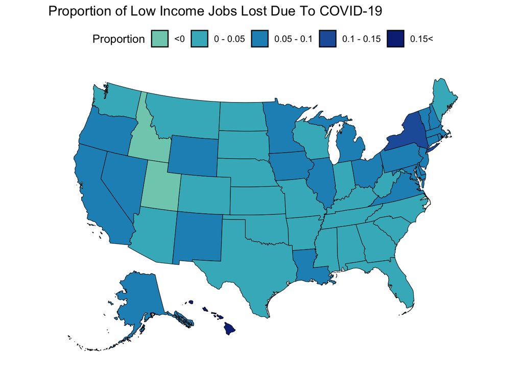

### [Rate of Vaccination](https://covid.cdc.gov/covid-data-tracker/#vaccinations_vacc-total-admin-count-total)

This data was collected by the CDC, which highlights the COVID-19 vaccination distribution per state. It includes the number of people receiving at least one dose, the number of people who are fully vaccinated, and the number of people with an updated (bivalent) booster dose based on information reported to the CDC on dose number, dose manufacturer, administration date, recipient ID, and date of submission. This dataset was last updated on May 10, 2023. CDC estimates are based on data that include a dose number (first, second, or booster). To protect the privacy of vaccine recipients, the CDC receives data without any personally identifiable information (deidentified data). Each jurisdiction or provider uses a unique person identifier to link records within their own systems.

### [Length of Vaccine Availability](https://covid.cdc.gov/covid-data-tracker/#vaccinations_vacc-total-admin-count-total)

This data was collected by the CDC, which highlights the COVID-19 vaccination distribution per state. It includes the number of people receiving at least one dose, the number of people who are fully vaccinated, and the number of people with an updated (bivalent) booster dose based on information reported to the CDC on dose number, dose manufacturer, administration date, recipient ID, and date of submission. This dataset was last updated on May 10, 2023.

### Length of Masking Requirement

This dataset highlights the duration (in days) of masking requirements per state in response to the COVID-19 pandemic. The data was obtained from the Ballotpedia website, where researchers gathered information from each state’s local website. The dataset was last updated on April 30, 2022. It includes the start date, end date, and the type of order that terminated the state requirement. The termination reasons encompass executive orders, court orders, and legislative actions. Throughout the pandemic, some states adjusted their masking requirements or had temporary pauses, which are also indicated in the dataset.

### [Gathering Restrictions (Max Length)](https://healthdata.gov/dataset/U-S-State-and-Territorial-Gathering-Bans-March-11-/8tfm-md2h/data?no_mobile=true%E2%80%8B)

The variable “Gathering Restrictions (max length)” was derived from the gathering bans dataset obtained from the Health Data Gov. website. This dataset provides information on gathering restrictions at the county level in each state. The “max length” variable was created by calculating the longest duration, in terms of days, of gathering bans or limitations within any county in each state. This includes both complete bans on gatherings and restrictions on the size of gatherings, such as a limit on gatherings larger than six people. Health Data Gov. collected this data by referring to the local government websites of each county or state.

### [Healthcare Rank](https://www.usnews.com/news/best-states/articles/methodology)

The data for the health rankings of each state was obtained from the U.S. News 2021 rankings. This dataset provides a ranking from 1 to 50 for each state based on various factors, including healthcare access, healthcare quality, and public health. U.S. News calculates an overall ranking for each state by considering these factors. To ensure comparability between states, U.S. News utilizes a z-score distribution to scale each state’s ranking relative to all other states.

The metric-level results within the dataset range from 0 to 100, where the state with the best performance receives a score of 100, and the state with the worst performance receives a score of 0. All other states are then scaled proportionally between these two extremes. This scaling process allows for a standardized comparison of states’ performances across the metrics.

The data collection process involved surveying a random sample of 20 to 26 thousand Americans over three years. The survey included questions specifically related to the weighted categories used in the rankings. Respondents’ answers were weighted based on their ranking of healthcare importance in their respective states, ranging from one to eight. The results were also weighted to ensure representation of the country’s population across various demographics, including age, gender, ethnicity, and household income.

In addition to the survey data, the health rankings incorporate data sourced from local and government data agencies. These agencies provide specific information related to the three metrics that contribute to each state’s health ranking. The following is a list of each sub-variable in the central three metrics mentioned above:

#### Health Care Access:

| Sub-Variable | Source |
| --- | --- |
| Population Without Health Insurance | U.S. Census Bureau American Community Survey |
| Child Dental Visits | Centers for Medicare & Medicaid Services |
| Child Wellness Visits | Centers for Medicare & Medicaid Services |
| Adults Without Dental Visit | Centers for Disease Control and Prevention |
| Adults Without Wellness Visit | Centers for Disease Control and Prevention |
| Adults Deterred From | Centers for Disease Control and Prevention |

#### Health Care Quality:

| Sub-Variable | Source |
| --- | --- |
| Preventable Hospital Admissions | Centers for Medicare & Medicaid Services |
| Medicare Enrollees With Top-Quality Coverage | Centers for Medicare & Medicaid Services |
| Nursing Home Quality Rating | U.S. News Best Nursing Homes |
| Hospital Quality Rating | U.S. News Best Hospitals |

#### Public Health:

| Sub-Variable | Source |
| --- | --- |
| Infant Mortality Rate | Centers for Disease Control and Prevention |
| Mortality Rate | Centers for Disease Control and Prevention |
| Obesity Rate | Centers for Disease Control and Prevention |
| Smoking Rate | Centers for Disease Control and Prevention |
| Poor Mental Health | Centers for Disease Control and Prevention Centers for Disease Control and Prevention |
| Suicide Rate | Centers for Disease Control and Prevention |

### [Proportion of Democratic Voters](https://www.cookpolitical.com/2020-national-popular-vote-tracker)

The data was collected by the Cook Political Report, tracking the electoral vote counts for each state for the 2020 presidential election. It represents the number of votes each party received in each state, whether Democratic (Biden Votes – blue), republican (Trump Votes – red), or other (third-party). Additionally, the tracker shows each party’s share for each state in percentage.

### [Rate of Jobs that went Remote](https://www.teamflowhq.com/blog/states-where-the-most-people-worked-remote-because-of-covid-19)

This data was collected by the U.S. Census Bureau’s Household Pulse Survey in 2021. This data was collected from mid-April, at which point vaccines first became available to all adults, through early July, when cases began to rise significantly. It includes the ranks of each state, the proportion of remote workers, the percentage of adults in households with a remote worker, the total number of adults in households with a remote worker, the percentage of adults in households with expected income loss, the percentage of adults in households with difficulty paying expenses, and the median household income in each state.

To determine the states where the highest proportion of people worked remotely because of COVID-19, researchers used data from this survey to calculate the percentage of adults in households where at least one adult worked from home because of the coronavirus pandemic in the past seven days, averaged over the survey weeks during which this question was asked. Notably, this only includes those who worked remotely because of the pandemic and not those who would have done so regardless. In the event of a tie, the state with the higher number of adults in these households was ranked higher.

## Key Statistical Tests

### Hypothesis Testing

In our analysis, hypothesis testing was employed to assess the existence of a correlation between the proportion of low-income jobs lost and each variable under consideration. In all the tests conducted, we utilized an alpha value of 0.05 as the threshold for determining statistical significance, assuming that a correlation exists between the variables.

The null hypothesis ($H_0$) for all the tests posits that there is no correlation between the variable being examined and the proportion of low-income jobs lost. On the other hand, the alternative hypothesis ($H_A$) for all the tests assumes the presence of a meaningful statistical relationship between the variable and the proportion of low-income jobs lost.

### Principal Component Analysis

Using the Principal Component Analysis, we were able to bring our seven interrelated variables down to fewer variables that still accounted for a lot of the variability with the explanatory variable. Using standardization, we were able to put all of the variables on an even footing to ensure that no variable had more weight than another. Our goal with this was to create a more reasonable model that gave the data room to be unaffected by co-linearity. Using the Principal Component Analysis, we created a model that predicted low-income job loss based on two completely independent variables. In the end, we created a model that accounted for 91.8% of the variability in the explanatory variables. It is important when trying to predict using this model to plug in standardized versions to ensure that all variables are properly accounted for.

## Results

### Hypothesis Testing

#### Summary of Results

According to the following table, the eight variables’ p-values fall under the alpha level of 0.05. In terms of relationship strength, the majority of the variables have a moderate relationship with the proportion of low-income jobs lost per state, whether positive or negative. The length of masking requirement and the proportion of Democratic voters in 2020 both have a strong positive correlation with low-income jobs lost. The rate of jobs that went remote has a positive but weak relationship with low-income jobs lost.

| Variable | P-Value | Correlation Coefficient  | Relationship With PLIJs Lost |
| --- | --- | --- | --- |
| Rate of Vaccination | 1.497 × 10-5 | 0.57 | Moderate & Positive (Rate of Vaccination ↑, PLIJs Lost ↑)  |
| Length of Vaccine Availability | 6.24 x 10-6  | 0.60 | Moderate & Positive (Length of Vaccine Availability ↑, PLIJs Lost ↑)  |
| Length of Masking Requirement | 1.929 x 10⁻⁷ | 0.70 | Strong & Positive (Length of Requirements ↑, PLIJs Lost ↑) |
| Gathering Restrictions (Max Length) | 0.0009606 | 0.45 | Moderate & Positive (Length of Gathering Restrictions ↑, PLIJs Lost ↑) |
| Average Salary (per state, 2021) | 0.00113 | 0.45 | Moderate & Positive (Average Salary ↑, PLIJs Lost ↑) |
| Healthcare Rank (2021) | 0.001125 | -0.50 | Moderate & Negative (Healthcare rank ↑, PLIJs Lost ↓) |
| Proportion of Democratic Voters (2020) | 2.97 × 10-8 | 0.68 | Strong & Positive (Prop. of Democratic voters ↑, PLIJs Lost ↑)  |
| Rate of Jobs that went Remote |  0.04745 | 0.29 | Weak & Positive (Rate of Jobs that went Remote ↑, PLIJs Lost ↑)  |

#### [Rate of Vaccination](https://covid.cdc.gov/covid-data-tracker/#vaccinations_vacc-total-admin-count-total)

When conducting a hypothesis test to examine the relationship between the estimated proportion of low-income jobs lost due to COVID-19 and the Rate of Vaccinations by state, the obtained p-value of 1.497 × 10-5 in which we reject the null hypothesis & correlation coefficient is 0.57.

These results signify a moderate positive correlation between the proportion of low-income jobs lost per state (by population) and the length of vaccine availability in the US (by each state). Furthermore, the 95% confidence interval of (0.3702306, 0.7418059) does not include 0, which further supports the conclusion that there is a relationship between these variables. This tells us that the more vaccination rates were administered & distributed, the more jobs were lost due to COVID-19 vaccination regulations, and many companies or businesses started to require these doses, which could have led to some complications.

The graph below represents the relationship between the rate of vaccinations (Total Doses Administered per state) and the proportion of jobs lost. What does this mean? Certain states either pushed for vaccinations less compared to others, or the citizens of the states were not interested in getting vaccinated. Does that mean the less strict a state is, the fewer jobs it lost? You would assume that if a state is stricter, then they would be able to reopen businesses faster, thus losing fewer workers? Many businesses & states pushed for vaccinations & probably made it mandatory to work so that is why some states have more vaccinations administered.

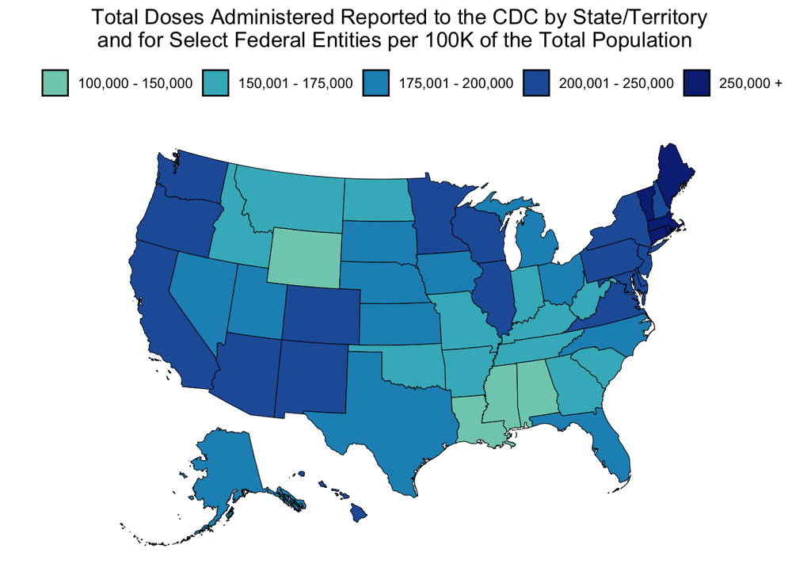

#### [Length of Vaccine Availability](https://covid.cdc.gov/covid-data-tracker/#vaccinations_vacc-total-admin-count-total)

Before doing the hypothesis testing, we had to compute the proportion of people who are vaccinated vs proportion of low income jobs lost in which we divided the percent total population with a completed series to examine the relationship between the estimated proportion of low-income jobs lost due to COVID-19 and the Length of Vaccine Availability (by each state, the obtained p-value of 6.24 x 10-6 in which we reject the null hypothesis & correlation coefficient is 0.60.

These results signify a moderate positive correlation between the proportion of low-income jobs lost per state (by population) and the length of vaccine availability in the US (by each state). Furthermore, the 95% confidence interval of (0.3702306, 0.7418059) does not include 0, which further supports the conclusion that there is a relationship between these variables.

In this graph, we wanted to highlight the duration of vaccine availability. If the availability and distribution of vaccines are delayed or prolonged, it can extend the duration of the COVID-19 pandemic. This, in turn, can have severe economic consequences, including business closures, reduced consumer spending, and job losses across various sectors. Low-income workers are often employed in industries that have been disproportionately affected by the pandemic, such as hospitality, retail, and personal services, making them particularly vulnerable to job losses. Also, this issue can result in shifts and changes within industries. Some businesses may struggle to sustain their operations for an extended period, leading to closures or downsizing. This can lead to job losses, particularly for low-income workers employed in sectors that are heavily impacted and unable to adapt to changing market conditions.

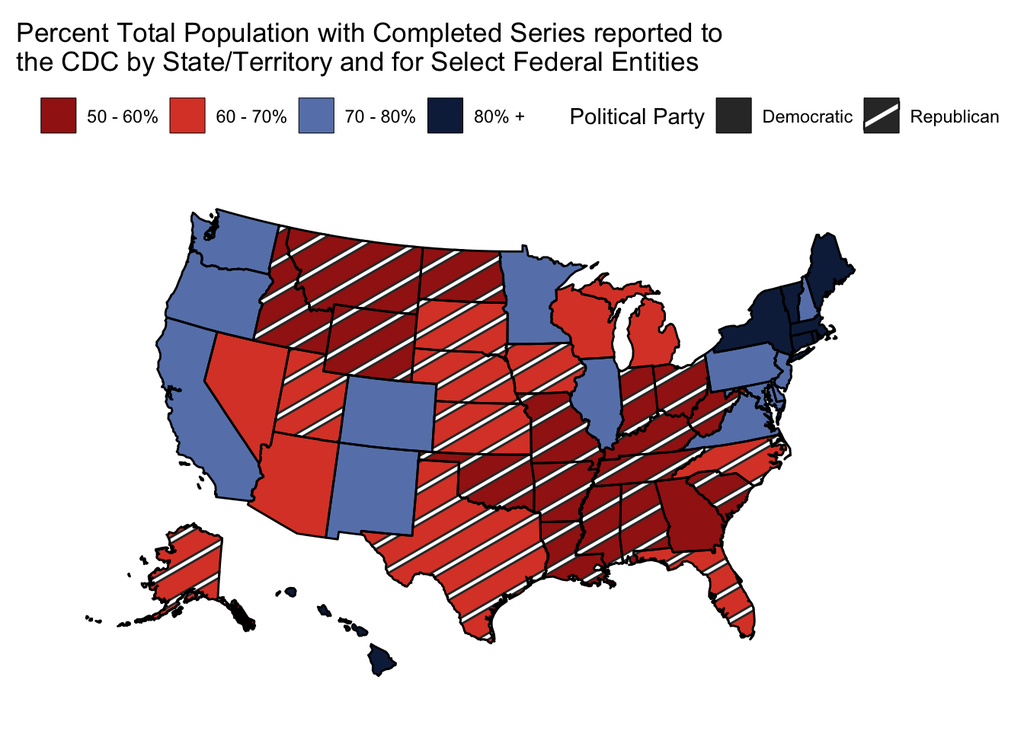

#### Length of Masking Requirement

When conducting a hypothesis test to examine the relationship between the estimated proportion of low-income jobs lost due to COVID-19 and the duration of masking requirements, the obtained p-value and correlation coefficient were 1.929*10^(-7) and 0.70, respectively. These results signify a strong, positive correlation between the estimated proportion of low-income jobs lost per state and the length of masking requirements. Therefore, states with lengthier masking requirements are expected to experience a higher proportion of job losses.

The following graphic illustrates the connection between the duration of masking requirements, the proportion of job losses, and the political leaning of states in the 2020 primary elections. States with lengthier masking requirements tend to occupy the upper section of the plot, where a higher proportion of low-income jobs were lost. This section is predominantly populated by Democratic-majority states. In contrast, Republican-majority states generally exhibit shorter or no masking requirements, and they report smaller proportions of low-income jobs lost to the pandemic.

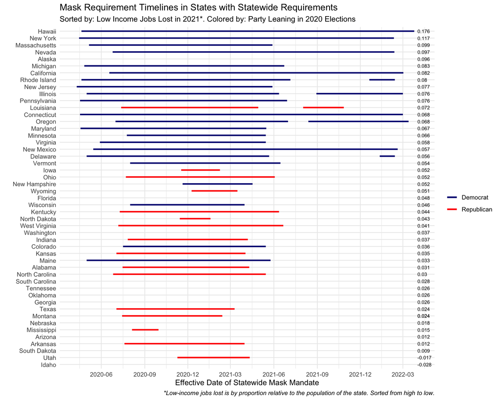

#### [Gathering Restrictions (Max Length)](https://healthdata.gov/dataset/U-S-State-and-Territorial-Gathering-Bans-March-11-/8tfm-md2h/data?no_mobile=true%E2%80%8B)

Hypothesis testing between the max gathering bans variable and low-income jobs lost provided a p-value and correlation coefficient of 9.6*10^(-4) and 0.45, respectively. Based on these findings, we conclude that there is a positive and moderate correlation between the two variables. In other words, an increase in the duration of gathering restrictions is associated with a higher proportion of low-income jobs lost.

The visual below illustrates the relationship between these variables. The plot is arranged in descending order of the proportion of low-income jobs lost in each state, ranging from high to low. It can be observed that states with longer gathering restrictions tend to exhibit a higher proportion of low-income jobs lost. Due to the moderate correlation between the variables, discerning the pattern in such a plot can be challenging compared to, for instance, the duration of masking requirements.

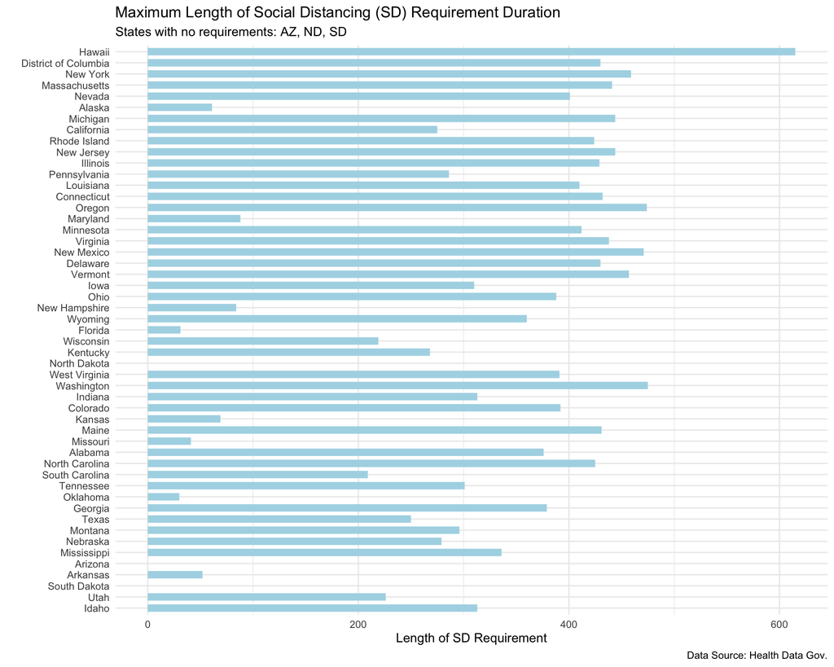

#### [Average Salary per State](https://www.statista.com/statistics/243850/private-industry-wages-per-employee-in-the-us-by-state/)

According to the hypothesis test on the relationship between average salary and low-income jobs lost, a p-value of 0.00113 and a correlation coefficient of 0.447 are provided. We conclude that there is a moderate correlation between the proportion of low-income jobs lost per state (by population) and the average salary per state. This means that an increase in annual wage is associated with a higher proportion of low-income jobs lost.

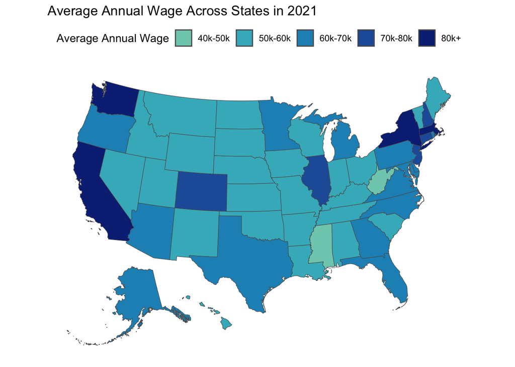

#### [Rate of Jobs that went Remote](https://www.teamflowhq.com/blog/states-where-the-most-people-worked-remote-because-of-covid-19)

When conducting a hypothesis test to examine the relationship between the estimated proportion of low-income jobs lost due to COVID-19 and the Rate of Jobs that went Remote, the obtained p-value of 0.04745 in which we reject the null hypothesis & correlation coefficient is 0.29.

These results signify a weak but positive correlation between the proportion of low-income jobs lost per state (by population) and the Proportion of jobs that went remote due to COVID-19 in the US (by each state). Furthermore, the 95% confidence interval of (0.003690818, 0.519365939) does not include 0, which further supports the conclusion that there is a relationship between these variables. This tells us that many people had to transition into remote jobs due to COVID-19, which could have caused an increase in job loss due to strict COVID-19 regulations made by many companies or businesses.

This graph shows the relationship between these two variables. We wanted to highlight how big of an impact the COVID-19 pandemic had on the work industry in the US, how many people had to transition into doing remote work, and how it also had an impact on people losing their jobs as well. Remote work allows companies to hire employees from anywhere, leading to increased competition for certain jobs. Low-income workers who were previously employed in industries that are now remote-capable may face difficulties in securing remote positions. Another thing is that the shift to remote work can trigger broader structural changes in industries. For instance, reduced demand for office space, business travel, or in-person services can lead to downsizing or closures of businesses that predominantly employ low-income workers. The transition to remote work may not be feasible for industries that heavily rely on face-to-face interactions or physical presence.

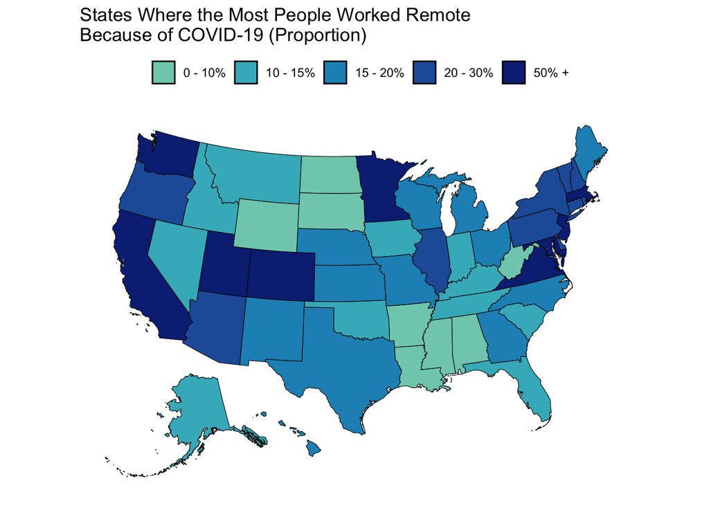

### PCA

By standardizing each variable and then plugging them into each component, we can then use the equation below to predict the proportion of low-income jobs that should have been lost to the COVID-19 pandemic.

## Discussion

We now see that only a higher average annual income in 2021 will heavily increase component two. We then also see that the total days of mask mandates and banned gathering sizes have a higher pull in the negative direction and help to compensate for over-predictions in the first component. It makes a lot of sense that the second component would be comprised mostly of pulling the proportions into reasonable ranges. Noting that the highest proportion of low-income jobs lost to COVID-19 was about 17.6% in our model, it makes sense that our variables would be low, and we would want our model to predict low numbers.

| Variable | Component 1 | Component 2 |
| --- | --- | --- |
| Health Care Rank 2021 | 0.5062862 | 0.1546764 |
| Doses of the COVID-19 Vaccine Administered | 0.5452783 | -0.0669683 |
| Proportion of Remote Workers | 0.4511370 | 0.2180179 |
| Total Days of Mask Mandate | 0.0448232 | -0.4008348 |
| Annual Income 2021 | -0.2988173 | 0.5507414 |
| Proportion of Democratic Voters in the 2020 Election | 0.3812887 | -0.0280959 |
| Gathering Size Ban | -0.0783530 | -0.6777054 |

Finally, we can see that by un-standardizing the variables and plugging each variable through the component, we can find ways to predict the proportion of low-income jobs lost due to COVID-19 based on each individual variable. We can see from the following equation what each variable would bring to each predictor and what the new intercept is.

Intercept $= -0.00446929$

Health Care Ranking Coefficient $= 0.00000275842$

Doses of Vaccine Administered Coefficient $= 0.00007061625$

Proportion of Remote Workers Coefficient $= 0.005828656$

Gathering Size Ban $= -0.000002022761$

While this model is less interpretable, it is great for using for predictions. Using these coefficients, we can get accurate predictions based on each variable’s value. This is as opposed to the following model, which gives a great idea of how each variable affects the model but is not as good at predicting.

Standardized Intercept $= 0.049508$

Standardized Health Care Ranking Coefficient $= 0.00646018546107$

Standardized Doses of Vaccine Administered Coefficient $= 0.00540624078874$

Standardized Proportion of Remote Workers Coefficient $= 0.006312696880526$

Standardized Total Days of Mask Mandate Coefficient $= -0.001245683021122$

Standardized Annual Income Coefficient $= 0.000572238398216$

Standardized Proportion of Democratic Workers Coefficient $= 0.003922719458163$

Standardized Gathering Size Ban $= -0.005312498982239$

While both models are useful, it is good to see how each variable affects the model and allows us to see that the standardized annual income coefficient has the least impact on the model when standardized and helps to see that the balance between component one and component two minimizes annual income while allowing for corrective elements to come in like gathering size ban and total days of mask mandate.

## GitHub Repository

Click [here](https://github.com/Yarrabozaed/Data-and-Society) to view our GitHub repository and code!